# Annotating AML mouse spleen Stereo-seq data using a matched scRNA-seq as bridge

First load necessary packages

```r
suppressPackageStartupMessages(library(PhiSpace))
suppressPackageStartupMessages(library(ggplot2))
suppressPackageStartupMessages(library(dplyr))
suppressPackageStartupMessages(library(magrittr))
suppressPackageStartupMessages(library(ggpubr))
suppressPackageStartupMessages(library(tidyr))
suppressPackageStartupMessages(library(qs))

suppressPackageStartupMessages(library(ComplexHeatmap))
suppressPackageStartupMessages(library(seriation))

source("utils.R")
dat_dir <- "/data/projects/punim0613/JiaDong/Dawson/MouseSpleen/"
```

# Finding meta-clones

Load the stereo-seq data. Here we choose Bin50, leading to bins of side length 25 microns (diameter of Visium spots is 55 microns).

See `prepareData.R` for data pre-processing.

```r
binsize <- 50
queryPath <- paste0(
    dat_dir, "stereo-seq_m4_additional_bin_sizes/mouse4_bin",
    binsize, "_bc_sce.qs"
)
if(!file.exists(queryPath)){

  query <- qread(queryPath)
  query <- RankTransf(query, "counts")
  query <- logTransf(query, targetAssay = "log1p", use_log1p = TRUE)
  qsave(query, queryPath)
} else {

  query <- qread(queryPath)
}
```

The object `query` contains gene expression data and metadata for the bins. Next we visualise the spatial location of the bins. We see a spleen section.

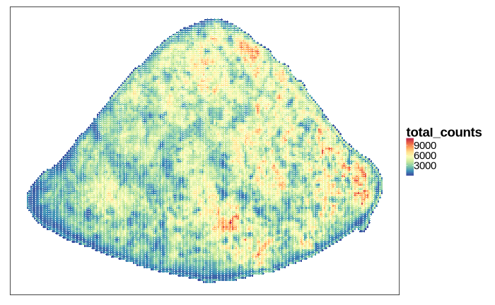

```r
p <- VizSpatial(query, ptSize = 1, groupBy = "total_counts") + scale_colour_gradientn(colours = MATLAB_cols)
p
```

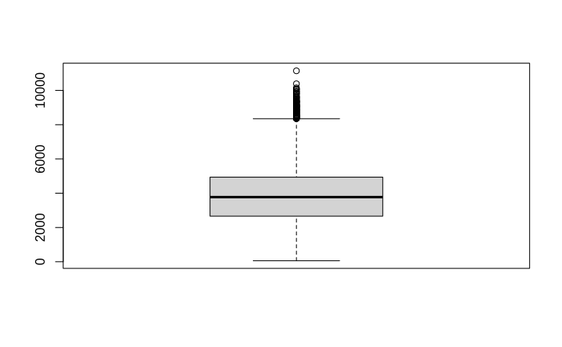

```r
boxplot(query$total_counts)
```

```r
quantile(query$total_counts, c(0,0.01,0.05,0.1))
```

```
    0%     1%     5%    10%
  58.0  583.1 1182.5 1712.0
```

```r
cell2keep <- colnames(query)[query$total_counts > quantile(query$total_counts, 0.01)]
query <- query[,cell2keep]
```

Next we load the barcode information, containing the spatial location of detected barcodes. We will convert the raw data object `bcRaw` to a ‘barcode-seq’ format comparable to stereo-seq data assays.

```r
bcRaw <- read.table(
  paste0(
    dat_dir,"stereo-seq_m4_additional_bin_sizes/mouse4_bin",
    binsize, "_bc_counts.tsv"
  ),
  sep = "\t", header = T, row.names = 1
)
bcRaw$bin_y <- -bcRaw$bin_y
bcRaw$y_center <- -bcRaw$y_center
isin_data <- (bcRaw$isin_adata == "True")
# Simplify barcode names
bcRaw$barcode <- gsub("GFP_", "", bcRaw$barcode)
# Bins that do not contain barcodes
noBarIdx <- setdiff(query$cell_id, bcRaw$cell_id[bcRaw$isin_adata == "True"])
```

# Visualisation of spatial distribution of clone

We visualise the spatial distributions of some of the dominating clones. This helps us see if a clone tends to concentrate within a spatial region, and if different clones tend to concentrate in different regions.

For this purpose we define some useful quantities for plotting.

```r
# Which coordinates to use
xCoordName <- "x_center"
yCoordName <- "y_center"
# X and Y limits
xylimits <- bcRaw[isin_data, c(xCoordName, yCoordName)] %>%
      apply(2, quantile, probs = c(0,1))
## Convex hull defining spleen region
ch <- colData(query)[, c("x", "y")] %>% as.matrix()
ch <- ch[chull(ch),]
sortedBC <- table(bcRaw$barcode) %>% sort(decreasing = T)
```

Plot the top 16 most abundant clones.

```r
sortedBC <- table(bcRaw$barcode) %>% sort(decreasing = T)

xx_eval <- bcRaw[, c(xCoordName, yCoordName)] %>%
  `colnames<-`(c("x", "y"))
out <- lapply(
  1:16,
  function(x){
    # Which clone
    bcName <- names(sortedBC)[x]
    # Data for density est
    xx <- bcRaw[bcRaw$barcode == bcName, c(xCoordName, yCoordName)]

    suppressWarnings(kde_res <- tempDenPlot(xx, xx_eval, xylimits, ch, F, psize = 0.1, bcName, spleenOnly = T))

    return(kde_res)
  }
)
estValues <- lapply(
  out, function(x) x$kde_res$estimate
) %>% unlist
estRange <- range(estValues)
outPlots <- lapply(
  out,
  function(x){
    p <- x$p
    suppressMessages(
      p <- p +
        scale_colour_gradientn(colours = MATLAB_cols, limits = estRange)
    )
  }
)
suppressWarnings(
  ggsave(
    "figs/spleen_densities.png",
      ggarrange(plotlist = outPlots, nrow = 4, ncol = 4, legend = "none"),
      width = 7.5, height = 7.5
  )
)
```

## Barcode filtering

To evaluate the spatial distribution of all the clones, instead of viewing them one by one, we aggregate the high abundance clones to make a ‘barcode-seq’ assay.

We first filter out low abundance barcodes. The idea is that, most barcodes have very low abundance (eg detected in only one bin) and it’s not very interesting analysing them. (However there is a possibility to utilise them for statitical inference. That is, we might be able to model the spatial distribution of those low abundance barcodes as a proxy to some sort of background noise.)

```r
sortedBC_filt <- sortedBC[sortedBC >= 50]
length(sortedBC_filt)
```

```
[1] 35
```

```r
bcFilt <- bcRaw %>%
  filter(barcode %in% names(sortedBC_filt)) %>%
  mutate(
    barcode = as.factor(barcode)
  )
```

Only 35 barcodes have reads no smaller than 50.

## Define barcode-seq assay

```r
binIDs <- unique(bcFilt$cell_id)
barAssayRaw <- sapply(
  1:length(binIDs),
  function(x){

    binID <- binIDs[x]
    idx <- (bcFilt$cell_id == binID)

    table(bcFilt[idx,"barcode"])

  }
) %>%
  t() %>%
  `rownames<-`(binIDs)
```

## Spatially enhanced bins

```r
xyRange <- 500
binIDs <- unique(bcFilt$cell_id)
barAssay <- sapply(
  1:length(binIDs),
  function(x){

    binID <- binIDs[x]
    coords <- bcFilt %>%
      filter(cell_id == binID)
    coords <- coords[1, c("x_center", "y_center")]

    xcond <- (abs(bcFilt$x_center - coords[1,1]) < xyRange)
    ycond <- (abs(bcFilt$y_center - coords[1,2]) < xyRange)
    idx <- xcond & ycond

    table(bcFilt[idx,"barcode"])

  }
) %>%
  t() %>%
  `rownames<-`(binIDs)
```

Now this barcode-seq assay has a similar interpretation as microbiome data, where counts of different taxa of bacteria are identified. Here the barcodes are our taxa.

A interesting statistical question is whether we need to normalise `barAssay` for downstream analysis. For example, we may define the total count of detected barcodes in the neibourhood of a bin as some sort of library size. Do we need to normalise this library size out? This depends on whether we think this library size contains biological information or not.

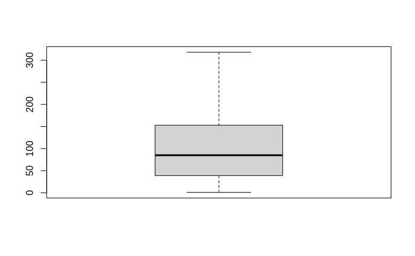

```r
libSizes <- rowSums(barAssay)
boxplot(libSizes)
```

Next we cluster the bins using the barcode-seq assay. Bins belonging to the same cluster tend to have similar composition of barcodes. We try different choices of number of clusters.

```r
plot_dat <- unique(
  bcFilt[,c("cell_id", xCoordName, yCoordName)]
) %>% as.data.frame()
clustPath <- paste0(dat_dir,"output/barcode-seq_clustering.rds")
if(!file.exists(clustPath)){

  set.seed(523423)
  outClusts <- lapply(
    2:10,
    function(kclust){

      clust_res <- kmeans(
        barAssay,
        centers = kclust,
        iter.max = 100,
        nstart = 50
      )

      return(clust_res)
    }
  )

  saveRDS(outClusts, clustPath)
} else {

  outClusts <- readRDS(clustPath)
}
```

Plot the clusters. To make the clusters comparable across different run of clustering, we align the clusters using the Hungarian algorithm implemented by `PhiSpace::align_clusters`.

```r
clust_list <- lapply(
  outClusts,
  function(x){
    factor(x$cluster, levels = sort(unique(x$cluster)))
  }
)
# Align clusters across different results
outPlots <- vector("list", length(clust_list))
for(x in length(clust_list):1){

  clust <- clust_list[[x]]

  if(x < length(clust_list)){
    clust_old <-  clust_list[[x+1]]
    clust <- align_clusters(clust, clust_old) %>% as.factor()
    clust_list[[x]] <- factor(clust, levels = as.character(sort(as.numeric(levels(clust)))))
  }

  plot_dat <- plot_dat %>%
    mutate(
      clusters = clust_list[[x]]
    )

  outPlots[[x]] <- tempClustPlot(plot_dat, T)
}
suppressWarnings(
  p <- ggarrange(
      plotlist = outPlots, nrow = 3, ncol = 3, legend = "none"
  )
)
suppressWarnings(
  ggsave(
    "figs/clusts/spleen_clusts.png",
    p, width = 6, height = 6
  )
)
png(
  paste0("figs/clusts/", "spleen_clusts_legend.png"),
  width = 0.5, height = 4, units = "in", res = 300
)
op <- par(mar = rep(0, 4))
suppressWarnings(grid::grid.draw(get_legend(outPlots[[length(outPlots)]])))
```

```r
par(op)
dev.off()
```

## Clone composition of clusters

To interpret the clusters, we look at clone composition of each cluster. We look at the non-aggregated counts (ie barcode counts in each individual bin).

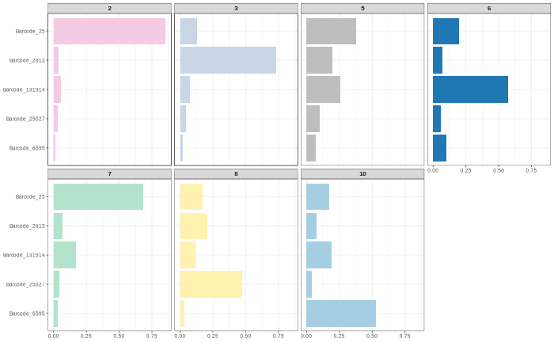

```r
clustIdx <- 7
clust <- clust_list[[clustIdx]]
barSelected <- names(sortedBC)[1:5]
plot_dat_wide <- barAssayRaw[,barSelected] %>% as.data.frame() %>%
  mutate(
    clust = clust
  ) %>%
  group_by(clust) %>%
  summarise(
    across(
      starts_with("Barcode"), sum
    )
  )

plot_prop <- plot_dat_wide %>% select(!clust) %>% as.matrix()
plot_prop <- (plot_prop/rowSums(plot_prop)) %>%
  as.data.frame() %>%
  mutate(
    clust = plot_dat_wide$clust
  ) %>%
  pivot_longer(
    !clust,
    values_to = "count",
    names_to = "barcode"
  ) %>%
  mutate(
    barcode = factor(
      barcode, levels = rev(barSelected)
    )
  )
plot_prop <- plot_prop %>% filter(clust != "9")
p <- plot_prop %>%
  ggplot(
    aes(count, barcode)
  ) +
  geom_bar(
    aes(fill = clust),
    stat = "identity"
  ) +
  theme_bw(base_size = 6) +
  scale_fill_manual(
    values = clust_cols
  ) +
  facet_wrap(~ clust, nrow = 2) +
  theme(
    legend.position = "none",
    axis.title = element_blank(),
    strip.text.x = element_text(size = 6, face = "bold")
  )
p
ggsave(
  "figs/clusts/clust_bc_composition.png",
  p, width = 4, height = 1.5
)
```

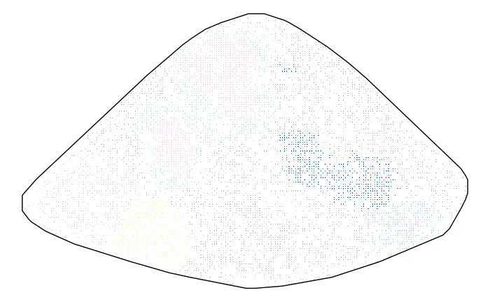

```r
p_clust <- outPlots[[clustIdx]] + theme_void(base_size = 8) +
  theme(
    legend.position = "none"
  )
p_clust
ggsave(
  "figs/clusts/clust_selected.png",
  p_clust, width = 2.2, height = 1.5
)
```

Use the following code to plot clustering results and clone compositions for different choices of `xyRange`.

See `bench_xyRange.R`.

# Some other characteristics of spatial data

Marker genes

```r
p1 <- VizSpatial(
  query, feature = "Marco", assay2use = "log1p", ptSize = 0.3
) +
  theme(
    legend.title = element_blank(),
    legend.position = "right",
    legend.key.spacing = unit(0, "pt")
  )
p2 <-VizSpatial(
  query, feature = "Cd74", assay2use = "log1p", ptSize = 0.3
) +
  theme(
    legend.title = element_blank(),
    legend.position = "right",
    legend.key.spacing = unit(0, "pt")
  )
p3 <-VizSpatial(
  query, feature = "Elane", assay2use = "log1p", ptSize = 0.3,
) +
  theme(
    legend.title = element_blank(),
    legend.position = "right",
    legend.key.spacing = unit(0, "pt")
  )
p4 <- VizSpatial(
  query, feature = "Slpi", assay2use = "log1p", ptSize = 0.3
) +
  theme(
    legend.title = element_blank(),
    legend.position = "right",
    legend.key.spacing = unit(0, "pt")
  )
png(
  "figs/spatialHeatMap/logGEX_leg.png",
  width = 0.5, height = 2, units = "in", res = 300
)
op <- par(mar = rep(0, 4))
grid::grid.draw(get_legend(p3))
par(op)
dev.off()
ggsave(
  "figs/spatialHeatMap/logGEX_Marco.png",
  p1 + theme(legend.position = "none"), width = 1.5, height = 1.2
)
ggsave(
  "figs/spatialHeatMap/logGEX_Cd74.png",
  p2 + theme(legend.position = "none"), width = 1.5, height = 1.2
)
ggsave(
  "figs/spatialHeatMap/logGEX_Elane.png",
  p3 + theme(legend.position = "none"), width = 1.5, height = 1.2
)
ggsave(
  "figs/spatialHeatMap/logGEX_Slpi.png",
  p4 + theme(legend.position = "none"), width = 1.5, height = 1.2
)
```

Density of barcoded bins.

```r
xx_eval <- colData(query)[query$barcode != "nan", c("x", "y")]
xx <- colData(query)[query$barcode != "nan", c("x", "y")]
suppressWarnings(
  kde_res <- tempDenPlot(xx, xx_eval, xylimits, ch, F, psize = 0.3, "", spleenOnly = F)
)
estValues <- kde_res$kde_res$estimate
estRange <- range(estValues)
p <- kde_res$p + scale_colour_gradientn(colours = MATLAB_cols, limits = estRange)
ggsave(
  "figs/spatialHeatMap/barcoded.png",
  p + theme(title = element_blank()), width = 1.5, height = 1.2
)
```

# PhiSpace

We use a bridging strategy to annotate the query Stereo-seq data. First using the four scRNA-seq references to annotate the AML spleen scRNA-seq data from Fennel et al. (2022) and then use this intermediate scRNA-seq data to annotate the query Stereo-seq data. Note that the intermediate scRNA-seq and the Stereo-seq data were from the same mouse spleen.

See `runPhiSpace.R` for the annotation of the intermediate scRNA-seq dataset.

```r
querySC <- qread(
  paste0(dat_dir, "mouse4_scRNAseq_sce.qs")
)
pathPhiSc <- paste0(
  dat_dir,
  "output/Mouse4_scRNA-seq_PhiSc_list.rds"
)
impScPath <- paste0(
  dat_dir,
  "output/ImpScores_for_Mouse4_scRNA-seq.rds"
)
scPhiSc_list <- readRDS(pathPhiSc)
reducedDim(querySC, "PhiSpace") <- do.call("cbind", scPhiSc_list)
newNames <- c(
  "RBC", "CD8 T", "Plasma", "Mature B", "cDC",
  "NK", "Neutro", "CD4 T", "Cr2 B", "HSPC",
  "Trans B", "Mono", "T", "Pre-B cycl", "Endo",
  "Cd7+ NK", "Macro", "pDC", "Baso", "Pre-B",
  "Mono", "Naive B", "Granulo", "Macro", "Imm B",
  "HPC", "Late pro-B", "Imm NK", "ProEryThBla", "T",
  "ErythBla", "T3", "MAT 3", "MAT 2", "IMM 1",
  "MAT 4", "MAT 1", "IMM 2", "T1", "T2",
  "PreNeu", "MAT 5", "MZ B", "Trans B", "Mat B",
  "CD122+ B", "Ifit3+CD4 T", "CD4 T", "pDC", "CD8 T",
  "B1 B", "NKT", "Ifit3+ B", "NK", "GD T",
  "ICOS+ Tregs", "Tregs", "Ly6+ mono", "Neutro", "Cycl B/T",
  "cDC2", "Ly6- mono", "RedPulp macro", "RBC", "Mig DC",
  "Ifit3+CD8 T", "cDC1", "Act CD4 T", "Plasma", "MZ/Marco+ macro"
)
newNames <- paste0(
  newNames,
  rep(
    c("(Spleen)", "(BM)", "(Neutro)", "(CITE)"),
    sapply(scPhiSc_list, ncol)
  )
)
colnames(reducedDim(querySC, "PhiSpace")) <- newNames
```

PhiSpace annotation of the query Stereo-seq.

```r
querySC <- logTransf(querySC, targetAssay = "log1p", use_log1p = T)
PhiRes <- PhiSpaceR_1ref(
  querySC,
  query,
  response = reducedDim(querySC, "PhiSpace"),
  PhiSpaceAssay = "log1p",
  nfeat = 500,
  regMethod = "PLS",
  scale = FALSE
)
reducedDim(query, "PhiSpace") <- normPhiScores(PhiRes$PhiSpaceScore)
```

Visualise clones in phenotype space.

```r
tempSavePlots(
  query,  methodName = "PhiSpace", tissueName = "DawsonMouseSpleenAML",
  coordNames = c("x", "y"),
  freeColScale = T, censQuant = 0.5, returnPlot = F, psize = 0.8
)
```

Clustering based on PhiSpace scores.

```r
tempClustCols <- c(
  "1" = "#A65628", "2" = "#FFFF33", "3" = "#377EB8", "4" = "#FF7F00",
  "5" = "#F781BF", "6" = "#984EA3", "7" = "#E41A1C", "8" =  "#4DAF4A"
)
PhiPCRes <- getPC(
  reducedDim(query, "PhiSpace"), ncomp = ncol(reducedDim(query, "PhiSpace")) - 1
)
PhiPCRes$accuProps
```

```
 [1] 0.2176246 0.3560696 0.4465162 0.5061087 0.5476718 0.5880242 0.6237228 0.6567441 0.6871119
[10] 0.7151352 0.7396287 0.7626544 0.7837393 0.8028613 0.8198900 0.8359737 0.8499618 0.8633470
[19] 0.8755187 0.8871021 0.8980777 0.9076499 0.9171064 0.9258677 0.9337611 0.9411673 0.9475446
[28] 0.9529651 0.9582964 0.9628101 0.9670592 0.9710055 0.9745103 0.9774125 0.9801118 0.9822016
[37] 0.9842202 0.9859574 0.9873098 0.9884269 0.9893055 0.9900303 0.9905220 0.9909461 0.9912563
[46] 0.9915070 0.9916813 0.9917988 0.9919008 0.9919697 0.9920317 0.9920756 0.9921094 0.9921325
[55] 0.9921509 0.9921605 0.9921694 0.9921757 0.9921792 0.9921810 0.9921817 0.9921823 0.9921826
[64] 0.9921827 0.9921827 0.9921828 0.9921828 0.9921828 0.9921828
```

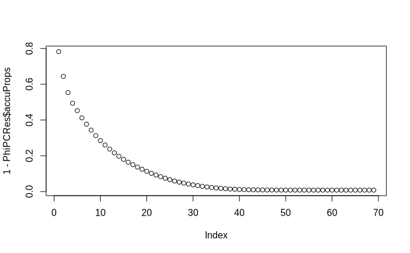

```r
plot(1-PhiPCRes$accuProps)
```

```r
mat2clust <- PhiPCRes$scores[,1:30]
names(tempClustCols) <- 1:8
set.seed(94863)
clust_res <- kmeans(
  mat2clust, centers = 8, iter.max = 200L, nstart = 50
)
query$PhiClust <- as.character(clust_res$cluster)

p <- VizSpatial(
  query, groupBy = "PhiClust", ptSize = 0.5
) +
  scale_colour_manual(values = tempClustCols) +
  guides(
    colour = guide_legend(
      override.aes = list(size = 2)
    )
  ) +
  theme(
    legend.title = element_text(face = "bold"),
    legend.position = "right",
    legend.key.spacing = unit(0, "pt")
  )
p
png(
  "figs/clusts/PhiClust_leg.png",
  width = 0.5, height = 2, units = "in", res = 300
)
```

```r
op <- par(mar = rep(0, 4))
grid::grid.draw(get_legend(p))
par(op)
dev.off()
```

[figure not shown]

```r
ggsave(
  "figs/clusts/PhiClust.png",
  p + theme(legend.position = "none"),
  width = 2, height = 1.8
)
```

```r
clustMeans <- aggregate(
  reducedDim(query, "PhiSpace"),
  list(query$PhiClust),
  mean
)[,-1]
selectFeat(clustMeans %>% t)$orderedFeatMat[1:10,]
```

```
      [,1]              [,2]              [,3]                    [,4]
 [1,] "RBC(Spleen)"     "Mono(BM)"        "Trans B(CITE)"         "Trans B(Spleen)"
 [2,] "ProEryThBla(BM)" "cDC(Spleen)"     "Trans B(Spleen)"       "Trans B(CITE)"
 [3,] "RBC(CITE)"       "Mono(Spleen)"    "MAT 3(Neutro)"         "MAT 3(Neutro)"
 [4,] "IMM 1(Neutro)"   "Macro(Spleen)"   "T1(Neutro)"            "MAT 5(Neutro)"
 [5,] "Act CD4 T(CITE)" "T1(Neutro)"      "MAT 5(Neutro)"         "T1(Neutro)"
 [6,] "T2(Neutro)"      "MAT 3(Neutro)"   "ICOS+ Tregs(CITE)"     "Imm NK(BM)"
 [7,] "T1(Neutro)"      "Ly6+ mono(CITE)" "RedPulp macro(CITE)"   "MZ/Marco+ macro(CITE)"
 [8,] "HPC(BM)"         "MAT 4(Neutro)"   "Mature B(Spleen)"      "MAT 4(Neutro)"
 [9,] "Cycl B/T(CITE)"  "Trans B(Spleen)" "Imm NK(BM)"            "RedPulp macro(CITE)"
[10,] "T3(Neutro)"      "Neutro(CITE)"    "MZ/Marco+ macro(CITE)" "Mature B(Spleen)"
      [,5]                [,6]               [,7]                [,8]
 [1,] "HPC(BM)"           "RBC(CITE)"        "Neutro(Spleen)"    "Neutro(CITE)"
 [2,] "pDC(Spleen)"       "ErythBla(BM)"     "ICOS+ Tregs(CITE)" "T1(Neutro)"
 [3,] "ICOS+ Tregs(CITE)" "RBC(Spleen)"      "Tregs(CITE)"       "PreNeu(Neutro)"
 [4,] "T1(Neutro)"        "HPC(BM)"          "Granulo(BM)"       "Cycl B/T(CITE)"
 [5,] "MAT 3(Neutro)"     "Mat B(CITE)"      "Neutro(CITE)"      "Mono(BM)"
 [6,] "T2(Neutro)"        "Imm NK(BM)"       "HPC(BM)"           "Trans B(Spleen)"
 [7,] "pDC(CITE)"         "ProEryThBla(BM)"  "T3(Neutro)"        "HSPC(Spleen)"
 [8,] "CD8 T(Spleen)"     "MAT 2(Neutro)"    "MAT 1(Neutro)"     "T(BM)"
 [9,] "cDC(Spleen)"       "IMM 2(Neutro)"    "pDC(Spleen)"       "Mig DC(CITE)"
[10,] "Ly6+ mono(CITE)"   "Mature B(Spleen)" "IMM 1(Neutro)"     "cDC(Spleen)"
```

```r
clustResPhi <- clust_res
```

Clustering based on PCs of gene expression.

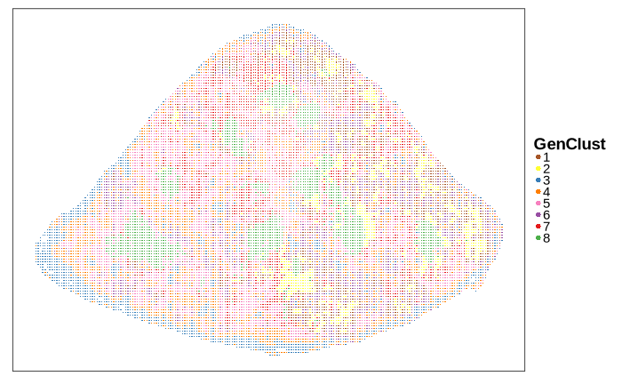

```r
clustResPhi <- clust_res
mat2clust <- getPC(
  t(assay(query, "log1p")), ncomp = 30
)$scores
set.seed(94858)
clust_res <- kmeans(
  mat2clust, centers = 8, iter.max = 200L, nstart = 50
)
query$GenClust <- align_clusters(as.character(clust_res$cluster), query$PhiClust)
p <- VizSpatial(
  query, groupBy = "GenClust", ptSize = 0.5
) +
  # scale_colour_brewer(palette = "Set1") +
  scale_colour_manual(values = tempClustCols) +
  guides(
    colour = guide_legend(
      override.aes = list(size = 2)
    )
  ) +
  theme(
    legend.title = element_text(face = "bold"),
    legend.position = "right",
    legend.key.spacing = unit(0, "pt")
  )
p
ggsave(
  "figs/clusts/OmicsClust.png",
  p + theme(legend.position = "none"),
  width = 2, height = 1.8
)
```

DWD analysis: barcoded vs nonbarcoded.

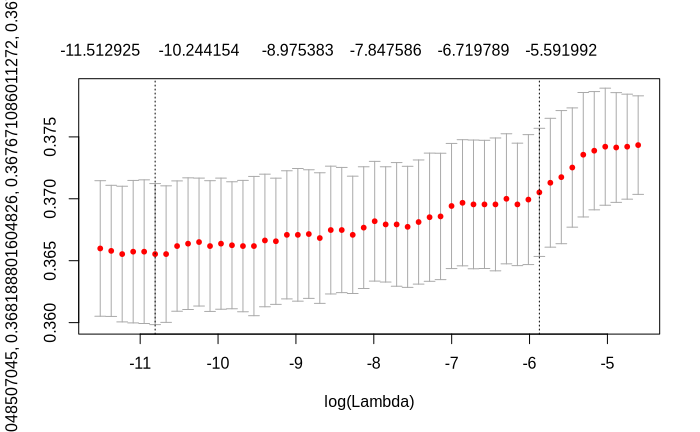

```r
library(kerndwd)
barcodeVec <- as.character(query$barcode)
barcodeVec[barcodeVec != "nan"] <- 1
barcodeVec[barcodeVec == "nan"] <- -1
barcodeVec <- as.numeric(barcodeVec)
X_cent <- reducedDim(query, "PhiSpace") %>% as.matrix()
X_cent <- scale(X_cent, center = T, scale = F)
lambda = 10^(seq(-2, -5, length.out=50))
kern = vanilladot()
cv_res = cv.kerndwd(X_cent, barcodeVec, kern, qval=1, lambda=lambda, eps=1e-5, maxit=1e5)
plot(cv_res)
```

```r
da_res = kerndwd(X_cent, barcodeVec, kern, qval=1, lambda=cv_res$lambda.min, eps=1e-5, maxit=1e5)
dwdLoad <- da_res$alpha[-1,,drop=F] %>% `dimnames<-`(list(colnames(X_cent),"comp1")) # worked out by looking at predict.dwd
dwdScore <- predict.kerndwd(da_res, kern, X_cent, X_cent, "link") %>% `colnames<-`("comp1")
dwd_res <- list(
  scores = dwdScore %>% as.data.frame(), loadings = dwdLoad %>% as.data.frame()
)
```

Visualise DWD results.

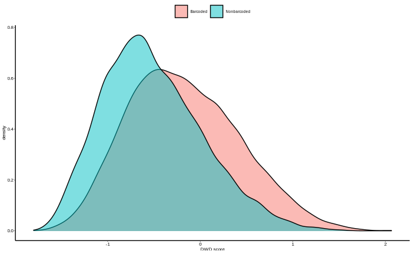

```r
barcodedOrNo <- barcodeVec
barcodedOrNo[barcodeVec==1] <- "Barcoded"
barcodedOrNo[barcodeVec==-1] <- "Nonbarcoded"
p_dens <- dwd_res$scores %>%
  mutate(
    niche = barcodedOrNo
  ) %>%
  ggplot() +
  geom_density(
    aes(comp1, fill = niche), alpha = 0.5
  ) +
  theme_pubr(base_size = 6) +
  theme(
    legend.title = element_blank()
  ) +
  xlab("DWD score")
p_load <- loadBarplot(
  dwd_res$loadings, comp = "comp1", showInt = F,
  nfeat = 10, fsize = 7, xlab = "DWD loading", absVal = T
)
p_dens
```

```r
p_load
ggsave(
  "figs/DWD_barcoded_dens.png",
  p_dens, width = 2, height = 1.5
)
```

[figure not shown]

```r
ggsave(
  "figs/DWD_barcoded_load.png",
  p_load, width = 2, height = 1.7
)
```

Boxplots: which cell types enriched in which clone cluster

```r
clustBar <- clust_list[[clustIdx]] %>%
  `names<-`(rownames(barAssay)) # containing all barcoded bins in and out spleen
plot_dat <- reducedDim(query, "PhiSpace") %>% as.data.frame()
clustBar <- clustBar[
  intersect(rownames(plot_dat), names(clustBar)) # all barcoded bins in spleen
]
clust <- rep("background", nrow(plot_dat))
names(clust) <- rownames(plot_dat)
clust[names(clustBar)] <- as.character(clustBar)
# Select some clusters
selectedClust <- c(
  "2", "3", "5", "6", "7", "8", "10", "background"
)
clust <- clust[clust %in% selectedClust]
clust <- factor(
  clust, levels = selectedClust
)
plot_dat <- plot_dat[names(clust), ] %>%
    mutate(
      cluster = clust,
      x = query[,names(clust)]$x,
      y = query[,names(clust)]$y
    )
cTypes <- colnames(reducedDim(query, "PhiSpace"))
suppressWarnings(
  p_boxs <- tempSaveBox(
    plot_dat, cTypes, width = 7, height = 10, fignrow = 8, figncol = 9, fsize = 5, returnPlot = T
  )
)

p <- p_boxs[[1]] +
  theme_bw(base_size = 8) +
  theme(
    legend.position = "top",
    axis.text.y = element_text(),
    legend.title = element_text(face = "bold")
  ) +
  guides(
    fill = guide_legend(
      nrow = 1
    )
  )
png(
  paste0("figs/cTypeEnrichBoxplots/box_legend.png"),
  width = 5, height = 0.5, units = "in", res = 300
)
op <- par(mar = rep(0, 4))
suppressWarnings(grid::grid.draw(get_legend(p)))
```

```r
par(op)
dev.off()
```

Statistical tests: which clusters have significantly different cell time enrichment compared to background

```r
cTypes <- colnames(reducedDim(query, "PhiSpace"))
pvals <- sapply(
  cTypes,
  function(cType){

    sc_split <- split(
      reducedDim(query, "PhiSpace")[names(clust),cType],
      clust
    )
    bkgrd <- sc_split$background
    sc_split[["background"]] <- NULL
    testRes <- sapply(
      sc_split,
      function(x) wilcox.test(x, bkgrd)$p.value
    )
    # testRes <- testRes[levels(clust)]
    return(testRes)
  }
) %>% t()
fc <- sapply(
  cTypes,
  function(cType){

    sc_split <- split(
      reducedDim(query, "PhiSpace")[names(clust),cType],
      clust
    )
    bkgrd <- sc_split$background
    sc_split[["background"]] <- NULL

    foldChange <- sapply(
      sc_split,
      function(x) (mean(x) - mean(bkgrd))/sd(bkgrd)
    )
    # foldChange <- foldChange[levels(clust)]
    return(
      foldChange
    )
  }
) %>% t()
sigScores <- fc * (-log10(pvals)) # feature significance score
# most enriched
tab <- selectFeat(sigScores, absVal = F)$orderedFeatMat[1:5, colnames(sigScores) != "9"]
knitr::kable(tab)
write.csv(tab, "figs/tab_enrich_cluster.csv")
# most depleted
tab <- selectFeat(-sigScores, absVal = F)$orderedFeatMat[1:5, colnames(sigScores) != "9"]
knitr::kable(tab)
write.csv(tab, "figs/tab_depleted_cluster.csv")
```

[output not shown]